# Web Scraping pada Website Bukalapak Menggunakan Python

Web Scraping adalah mengambil sebuah dokumen semi-terstruktur dari internet, umumnya berupa halaman-halaman web dalam bahasa markup seperti HTML atau XHTML, dan menganalisis dokumen tersebut untuk diambil data tertentu dari halaman tersebut. Web scraping banyak digunakan untuk mengambil data cuaca yang nantinya akan digunakan untuk prakiraan cuaca, kemudian data film dari sebuah website yang kemudian digunakan untuk analisis bisnis sebuah rumah produksi film, ada pula yang mengambil data harga sebuah produk dari marketplace yang nantinya digunakan untuk membandingkan harga produk tersebut.

Bukalapak merupakan sebuah e-commerce jual beli online yang menyediakan berbagai macam barang untuk kebutuhan sehari hari via website maupun aplikasi mobile. Web scraping pada website Bukalapak kali ini akan mengambil beberapa data dari produk populer yang ada pada kategori Kecantikan. Data yang berhasil diambil kemudian akan dibuat visualisasi datanya untuk dianalisis lebih lanjut.

Sebelum memulai scraping web menggunakan python ada beberapa hal yang perlu disiapkan. Pertama, kita harus menginstall library yang diperlukan untuk scraping web yaitu "request" dan "bs4". Pada library "bs4" kita akan menggunakan sebuah fungsi yang bernama BeautifulSoup yang berguna untuk proses pengambilan data pada website. Untuk menginstall package tersebut, lakukan langkah di bawah ini pada Anaconda prompt di PC anda:

- pip install requests
- pip install bs4

## Proses Scraping

```python
from bs4 import BeautifulSoup
from urllib.request import urlopen as uReq
```

Pada proses scraping web kali ini, saya melakukan scraping pada website Bukalapak sejumlah 7 halaman dimulai dari halaman pertama pencarian.Kata kunci yang saya gunakan adalah kata 'lipstik' dengan batasan rating dari 1 sampai dengan 5. Masing-masing halaman terdiri dari 50 data yang dapat di cek pada syntax #print(len(all_product)). Sebelum itu, cek dahulu apakah website bisa di scrape untuk di ambil datanya. Jika status koneksi = 200 maka website dapat di scrape. Data-data yang berhasil di scrape kemudian di write ke dalam format .csv agar mudah dibaca dan dianalisis kemudian. Pada proses scraping kali ini, data yang berhasil di scrap adalah sebanyak 350 data dan 6 kolom.

[figure not shown]

```python
csv=open("db_bukalapak.csv", 'w')

#membuat header (nama kolom) pada file db_bukalapak.csv
headers = "nama_produk,harga,penjual,kota,rating_produk,jml_review\n"
csv.write(headers)

#scraping 3 halaman yang ada di website bukalapak
for page in range(1,8):
    #link yang akan di scrape
    base_url = 'https://www.bukalapak.com/products/s?page='+str(page)+'&search%5Bbrand_seller%5D=0&search%5Bcity%5D=&search%5Bcourier%5D=&search%5Bfree_shipping_coverage%5D=&search%5Bhashtag%5D=&search%5Binstallment%5D=0&search%5Bkeywords%5D=lipstik&search%5Bnew%5D=1&search%5Bprice_max%5D=&search%5Bprice_min%5D=&search%5Bprovince%5D=&search%5Brating_gte%5D=1&search%5Brating_lte%5D=5&search%5Btodays_deal%5D=0&search%5Btop_seller%5D=0&search%5Bused%5D=1&search%5Bwholesale%5D=0&utf8=%E2%9C%93'
    #print(base_url)

    #Request URL dan parser web
    uClient = uReq(base_url)
    page_html = uClient.read()
    uClient.close()
    page_soup = BeautifulSoup(page_html, "html.parser")
    all_product = page_soup.find_all("div", class_ = "product-card")
    #print(len(all_product))

    #list data apa saja yang akan diambil dari produk
    for item in all_product:

        # nama  dan link product
        product_name = item.find("a", {"class":"product__name line-clamp--2 js-tracker-product-link qa-list"})
        #product_link = 'https://www.bukalapak.com' + str(product_name.get('href'))
        product_name = product_name.text.replace('\n', "").strip()

        # harga
        product_price = item.find("span", {"class":"amount positive"})
        product_price = product_price.text.replace('\n', "").strip()
        product_price = 'Rp ' + product_price

        #penjual
        seller_name = item.find("h5", {"class":"user__name"})
        seller_name = seller_name.text.replace('\n', "").strip()

        #kota pengiriman
        seller_city = item.find("span", {"class":"user-city__txt"})
        seller_city = seller_city.text.replace('\n', "").strip()

        #rating
        rating = item.find("div", {"class":"product__rating"})
        rating = rating.text.replace('\n', "").strip()
        rating = rating[0:3]

        #jumlah review
        review = item.find("div", {"class":"product__rating"})
        review = review.text.replace('\n', "").strip()
        review = review[3:]

        #write data yang sudah di scrape
        csv.write(product_name+','+ product_price+','+ seller_name+','+ seller_city+','+ rating+','+ review+'\n')
        #csv.write()
csv.close()
```

## Analisis dan Visualisasi Data

```python
import pandas as pd
import numpy as np
```

```python
import pandas as pd

bukalapak = pd.read_csv("data_input/db_bukalapak.csv")
bukalapak.head()
#print(bukalapak.dtypes)
```

|  | nama_produk | harga | penjual | kota | rating_produk | jml_review |
| --- | --- | --- | --- | --- | --- | --- |
| 0 | Shannen lipstik | Rp 99.000 | dian | Bandung | 4.5 | 6 ulasan |
| 1 | Wardah Lipstik Matte. Lipstik Matte Wardah | Rp 40.000 | Bunga Padi | Karawang | 4.2 | 8 ulasan |
| 2 | Lipstik 3ce Set Mini Kit | Rp 26.900 | Galeri Cantik Indonesia | Kab. Tangerang | 4.7 | 21 ulasan |
| 3 | SHANNEN LIPSTIK CREAMY PAINT LIPCREAM SHANNEN | Rp 89.900 | DSH SHOP | Bandung | 5.0 | 2 ulasan |
| 4 | Shannen Lipstik l Shanen Creamy Lipt | Rp 100.000 | Amalia Herbal | Tangerang | 4.8 | 12 ulasan |

Data di atas merupakan data penjualan produk lipstik pada e-commerce Bukalapak. Data tersebut merupakan kumpulan produk lipstik dari berbagai macam merk yang di diperoleh dari website Bukalapak dengan kata kunci pencarian berdasarkan relevansi. Deskripsi setiap kolom pada data bukalapak adalah sebagai berikut:

- `nama_produk` : Judul produk dalam etalase
- `harga` : Harga jual produk dalam etalase
- `penjual` : Nama penjual/seller
- `kota` : Kota pengiriman (asal penjual)
- `rating_produk` : Rating penjuala produk
- `jml_review` : jumlah review penjualan dari sebuah produk

```python
print(bukalapak.shape)
print(bukalapak.dtypes)
```

```
(350, 6)
nama_produk       object
harga             object
penjual           object
kota              object
rating_produk    float64
jml_review        object
dtype: object
```

Data bukalapak terdiri dari 350 data dan 6 kolom. Hasil cek tipe data masing-msing variabel di atas, terdapat beberapa variabel yang tidak sesuai tipe datanya. Sebelum mengganti ke tipe data yang benar, saya akan memfilter apa saja nilai yang akan saya ambil dari masing-masing variabel. Nilai-nilai yang akan saya ambil adalah sebagai berikut:

- nama_produk : diambil seluruh kata dan diganti tipe datanya menjadi category
- harga : menghilangkan karakter huruf 'Rp' dan tanda titik pemisah nominal (.) kemudian mengubah tipe datanya menjadi integer
- penjual : diambil seluruh kata dan diganti tipe datanya menjadi category
- kota : diambil seluruh kata dan diganti tipe datanya menjadi category
- jml_review : diambil angka (jumlah review) dan menghilangkan kata 'ulasan' kemudian mengubah tipe data menjadi integer

```python
bukalapak['harga'] = bukalapak['harga'].astype('category')
bukalapak['jml_review'] = bukalapak['jml_review'].astype('category')
print(bukalapak.dtypes)
```

```
nama_produk        object
harga            category
penjual            object
kota               object
rating_produk     float64
jml_review       category
dtype: object
```

```python
import re

bukalapak['harga'] = bukalapak['harga'].str.extract("(\d.+)",expand=True)
bukalapak['harga'] = bukalapak['harga'].astype('category')
bukalapak['harga'] = bukalapak['harga'].replace('[.]','',regex=True).astype(int)
```

Kode diatas adalah untuk mengubah format nominal harga "Rp 38.000" dengan tipedata category menjadi "38000" dengan tipe data integer.

```python
bukalapak['jml_review'] = bukalapak['jml_review'].str.extract("(\d+)",expand=True)
```

Kode diatas adalah untuk mengubah format jumlah review "4 ulasan" dengan tipedata category menjadi "4" dengan tipe data integer.

```python
print(bukalapak.dtypes)
```

```
nama_produk       object
harga              int32
penjual           object
kota              object
rating_produk    float64
jml_review        object
dtype: object
```

Cek apakah ada missing value di data.

```python
bukalapak.isna().sum()
```

```
nama_produk      0
harga            0
penjual          0
kota             0
rating_produk    0
jml_review       0
dtype: int64
```

Hasil di atas menunjukkan bahwa tidak ada ada missing value pada variabel di dataset bukalapak sehingga tidak perlu ada penanganan khusus untuk missing value.

```python
bukalapak[['jml_review','harga']] = bukalapak[['jml_review','harga']].astype('int64')
```

```python
bukalapak.head()
```

|  | nama_produk | harga | penjual | kota | rating_produk | jml_review |
| --- | --- | --- | --- | --- | --- | --- |
| 0 | Shannen lipstik | 99000 | dian | Bandung | 4.5 | 6 |
| 1 | Wardah Lipstik Matte. Lipstik Matte Wardah | 40000 | Bunga Padi | Karawang | 4.2 | 8 |
| 2 | Lipstik 3ce Set Mini Kit | 26900 | Galeri Cantik Indonesia | Kab. Tangerang | 4.7 | 21 |
| 3 | SHANNEN LIPSTIK CREAMY PAINT LIPCREAM SHANNEN | 89900 | DSH SHOP | Bandung | 5.0 | 2 |
| 4 | Shannen Lipstik l Shanen Creamy Lipt | 100000 | Amalia Herbal | Tangerang | 4.8 | 12 |

Setelah semua data sesuai dengan format yang kita mau, selanjutnya adalah memvisualisasikan data tersebut agar dapat dibaca dengan tampilan yang lebih menarik bagi pembaca. Pada visualisasi kali ini, saya menggunakan package altair seperti yang ada pada bahasa pemrogramaan R. Cara menginstal altair di python adalah sebagai berikut:

- pip install -U altair vega_datasets jupyterlab

**PENTING!!!**

Ketika running plot nanti Anda mengalami kegagalan, cek versi Jupyter(jika Anda menggunakan Jupyter) pada komputer Anda. Pastikan menggunakan versi Jupyter terbaru.

```python
import altair as alt
alt.renderers.enable('notebook')
```

```
RendererRegistry.enable('notebook')
```

### Segmentasi Produk

```python
bukalapak.describe()
```

|  | harga | rating_produk | jml_review |
| --- | --- | --- | --- |
| count | 3.500000e+02 | 350.000000 | 350.000000 |
| mean | 6.219829e+04 | 4.726857 | 18.088571 |
| std | 9.769807e+04 | 0.387881 | 35.829597 |
| min | 2.000000e+03 | 1.000000 | 1.000000 |
| 25% | 2.600000e+04 | 4.600000 | 3.000000 |
| 50% | 4.700000e+04 | 4.800000 | 8.000000 |
| 75% | 7.500000e+04 | 5.000000 | 19.000000 |
| max | 1.664500e+06 | 5.000000 | 367.000000 |

Hasil ringkasan statistika di atas akan saya gunakan untuk melakukan segmentasi produk berdasarkan harga dengan rincian sebagai berikut:

```python
q_harga = (bukalapak.harga.quantile([0.25, 0.5, 0.75])).to_list()
q_harga
```

```
[26000.0, 47000.0, 75000.0]
```

```python
kondisi = [
    (bukalapak.harga <= q_harga[1]),
    (bukalapak.harga <= q_harga[2]),
    (bukalapak.harga > q_harga[2])
]

kelas = ['Murah', 'Sedang','Mahal']

bukalapak['segmen_harga'] = np.select(kondisi, kelas, default='Mahal')
```

```python
bukalapak.segmen_harga.value_counts()
```

```
Murah     178
Sedang     87
Mahal      85
Name: segmen_harga, dtype: int64
```

Dari hasil di atas sekarang kita dapat mengetahui bahwa setengah data penjualan lipstik yang kita miliki tergolong dalam segmen harga murah. Artinya, produk lipstik yang banyak terjual dan laku di etalase adalah produk dengan harga kurang dari Rp 47.000,00. Untuk membuat informasi ini lebih menarik kita dapat memvisualisasikannya agar terbaca lebih mudah.

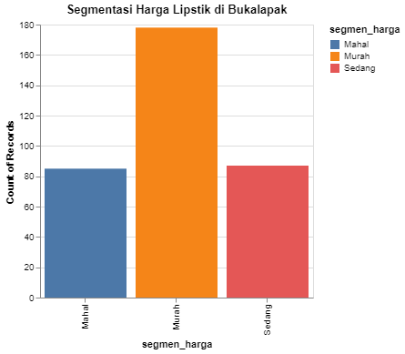

```python
bar=alt.Chart(bukalapak).mark_bar().encode(
    x = 'segmen_harga',
    y = 'count(segmen_harga)',
    color = 'segmen_harga',
    tooltip=['segmen_harga', 'count(segmen_harga)']
).interactive()
bar.properties(width=300, title='Segmentasi Harga Lipstik di Bukalapak')
```

### 10 Produk Lipstik yang Kurang Direkomendasikan

Sekarang kita akan kembali lagi ke tabel ringkasan statistika untuk merumuskan produk yang dinilai bagus dilihat dari jumlah rating dan review produknya.

```python
bukalapak.describe()
```

|  | harga | rating_produk | jml_review |
| --- | --- | --- | --- |
| count | 3.500000e+02 | 350.000000 | 350.000000 |
| mean | 6.219829e+04 | 4.726857 | 18.088571 |
| std | 9.769807e+04 | 0.387881 | 35.829597 |
| min | 2.000000e+03 | 1.000000 | 1.000000 |
| 25% | 2.600000e+04 | 4.600000 | 3.000000 |
| 50% | 4.700000e+04 | 4.800000 | 8.000000 |
| 75% | 7.500000e+04 | 5.000000 | 19.000000 |
| max | 1.664500e+06 | 5.000000 | 367.000000 |

```python
less_recomendation = bukalapak[(bukalapak.jml_review >=3)&(bukalapak.rating_produk < 4.5)].sort_values('rating_produk',ascending=False).tail(10)
```

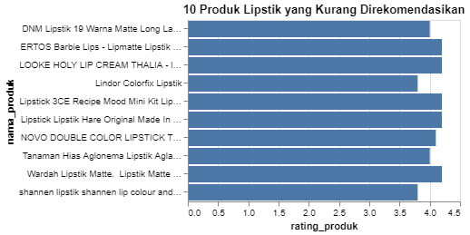

```python
bar=alt.Chart(less_recomendation).mark_bar().encode(
    x = 'rating_produk',
    y = 'nama_produk',
    tooltip=['nama_produk','penjual','harga','jml_review','rating_produk']
)
bar.properties(width=300, title='10 Produk Lipstik yang Kurang Direkomendasikan')
```

Berdasarkan visualisasi bar plot di atas, pada bagian axis Y kita dapat melihat nama produk lipstik yang kurang direkomendasikan untuk dibeli oleh konsumen Bukalapak. Hal ini dapat menjadi pertimbangan bagi pembeli ketika membeli produk lipstik di bukalapak, atau menjadi koreksi bagi penjual untuk meningkatkan kualitas barang yang dijual di tokonya. Ada beberapa hal yang membuat sebuah produk kurang direkomendasikan yaitu kondisi barang yang tidak sama dengan yang dipajang dan dideskripsikan di etalase, barang palsu, kondisi barang yang diterima rusak, dll. Namun, ada pertimbangan yang perlu diperhatikan bahwa visualisasi ini tidak serta merta dapat menjadi acuan mengingat kualitas produk di dunia nyata sangat bergantung ke banyak hal seperti kondisi barang yang rusak akibat pengiriman dan bukan merupakan kesalahan penjual atau kurangnya wawasan pembeli sehingga menilai produk yang dibelinya adalah barang palsu, dll.

### Distribusi Data Berdasarkan Rating dan Review Produk

Seringkali kualitas sebuah produk dikaitkan dengan nilai rating dan seberapa banyak orang yang telah memberikan review terhadap produk tersebut. Hal itu kemudian menjadi pertanyaan besar apakah benar nilai rating suatu produk akan dipengaruhi oleh seberapa banyak orang yang memberikan review terhadap produk tersebut. Kali ini, saya akan melihat persebaran data penjualan lipstik sebelumnya untuk menjawab apakah pertanyaan sebelumnya terbukti atau tidak.

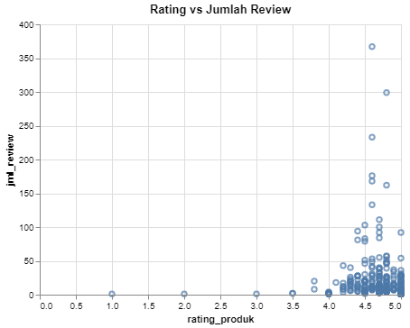

```python
my_chart = alt.Chart(bukalapak).mark_point().encode(
    x='rating_produk',
    y='jml_review',
    tooltip=['nama_produk','rating_produk','jml_review']
)
my_chart.properties(width=400, title='Rating vs Jumlah Review')
```

### Kota dengan Penjualan Terbanyak

```python
top_10_kota = pd.crosstab(index=bukalapak.kota,
           columns='jumlah_penjualan').sort_values('jumlah_penjualan', ascending=False).head(10).reset_index()
```

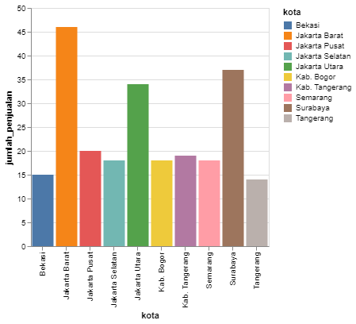

```python
bars = alt.Chart(top_10_kota.reset_index()).mark_bar().encode(
    x='kota',
    y='jumlah_penjualan:Q',
    color='kota',
    tooltip=['jumlah_penjualan']
).properties(width=300)
bars
```

Jakarta Barat menjadi kota yang paling banyak melakukan pengiriman produk lipstik kepada pembeli di Bukalapak. Rata-rata penjualan produk lipstik berasal dari daerah Jabodetabek. Melalui pendekatan ini, sebuah brand lipstik dapat menjadikannya patokan untuk melakukan pendistribusian produk dengan kuantitas yang lebih besar dari sektor wilayah lainnya.

## Kesimpulan

Scrapping merupakan salah satu cara untuk mengoleksi/mengumpulkan data ketika kita tidak punya akses langsung untuk mengambil data dari sebuah situs. Metode ini cukup efektif dalam mengumpulkan data karena cukup mudah dan tidak membutuhkan biaya banyak (bahkan bisa tanpa biaya). Akan tetapi tidak semua situs web dapat di scrap karena beberapa situs bersifat tertutup. Bukalapak menjadi salah satu website yang dapat diambil beberapa datanya sehingga kita dapat melakukan analisis terhadap sampel data yang kita ambil. Selain itu, data hasil scrapping juga dapat disimpan ke dalam berbagai format yang semakin memudahkan kita untuk melakukan analisis. Data yang berhasil diambil dari website Bukalapak pada latihan kali ini berjumlah 350 data yang memuat nama produk, penjual, kota pengiriman, harga, rating produk, dan jumlah review produk.